# R$ meta package를 이용해 forest plot 및 funnel plot 그리기

by **Youngjun Na**

December 12, 2017

in R packages

메타분석을 할 수 있는 R 코드입니다. 기본적인 effect size 계산과 forest plot 및 funnel plot을 그려보도록 하겠습니다.  
메타분석에 대한 소개는 다루지 않습니다. 자세히 공부해보고 싶으신 분은 [Introduction to Meta-Analysis](http://as.wiley.com/WileyCDA/WileyTitle/productCd-EHEP002313.html)란 책을 추천해 드립니다.

# 1. 데이터 정리

R의 `meta package`를 이용하여 분석을 진행합니다.  
엑셀 양식은 다음 [github](https://github.com/YoungjunNa/animal_science/blob/master/R/meta_dataframe.xlsx)에 제시하였습니다. 사실 어떤 양식으로 정리를 하던지 상관 없지만 아래의 코드를 사용하기 위해선 정해진 양식에 따라 정리를 해야 합니다.

메타분석을 아는 것 보다 중요한 것은 논문을 수집하고 수집된 각각의 논문을 정확하게 분석하고 입력하는 것입니다. 만약 사용할 데이터 자체가 잘못되었다면 분석은 의미가 없습니다. 메타분석은 단지 연구를 할 수 있는 하나의 툴일 뿐입니다. 달을 봐야 하는데 달을 가리키는 손가락만 보지 않기를 바랍니다.

# 2. R codes

먼저 `meta package`와 `dplyr package`를 설치합니다.

```r
install.packages("meta")
install.packages("dplyr")
install.packages("readxl")
```

설치한 김에 실행도

```r
library(dplyr)
library(meta)
```

setwd를 이용해 데이터의 위치(working directory)를 지정해 줍니다.

```r
setwd("E:/GitHub/animal_science")
```

사용할 데이터를 지정하고

```r
#read df
data<-readxl::read_excel("meta_dataframe.xlsx")
```

effect size를 계산하고 forest plot 및 funnel plot을 그려줄 함수를 만듭니다.

```r
#function
meta_function<-function(data, treats, responses){
  #packages
  require(meta)
  require(dplyr)

  #data filtering
  meta1<-filter(data, treat==treats)
  meta2<-filter(meta1, response==responses)

  #meta-analysis
  meta3<-metacont(n1,m1,s1,n2,m2,s2, sm="SMD", study, data=meta2)
  forest(meta3, leftcols="studlab", digits=3)
  funnel(meta3)
}
```

함수를 동작시킵니다.

```r
meta_function(data,"Sodium bicarbonate", "pH")
```

예쁘게 나옵니다.

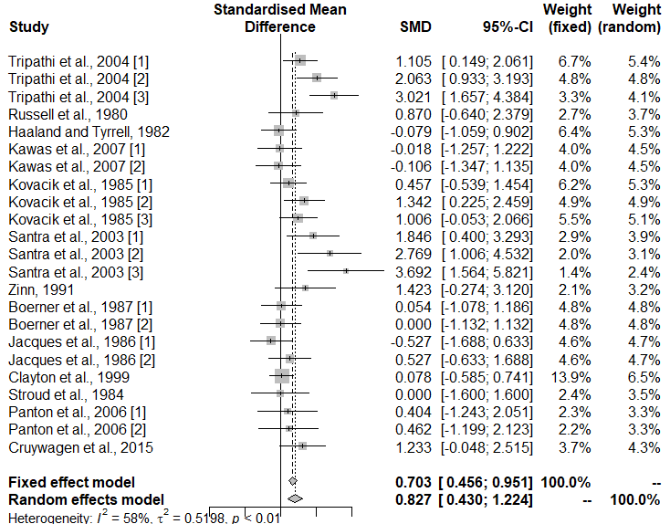

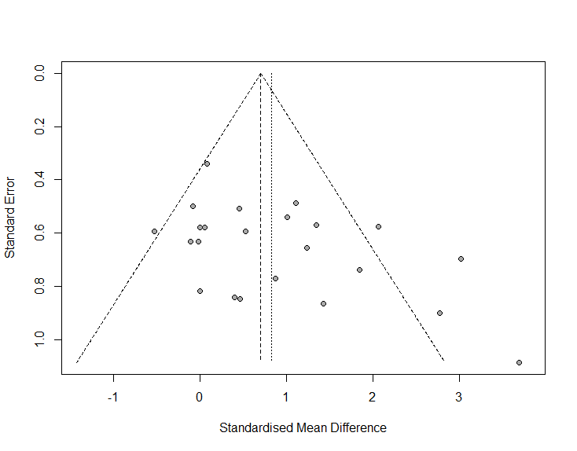

for 문을 이용해 조사한 모든 경우의 수를 분석하는 코드는 다음과 같습니다.

```r
#packages
library(meta)
library(dplyr)

#read df
df<-readxl::read_excel("meta_dataframe.xlsx")

#filtering the data
treat<-group_by(df, treat) %>% summarise() #grouping the treatment
n<-nrow(treat)

#for loop
for(i in 0:(n-1)){
  i=i+1
  trt<-treat[i,1]
  meta<-filter(df, treat==paste(trt[1,1]))

  response<-group_by(meta, response) %>% summarise() #grouping the response
  m<-nrow(response)

  for(j in 0:(m-1)){
    j=j+1
    resp<-response[j,1]

    meta1<-filter(meta, response==paste(resp[1,1]))
    meta2<-metacont(n1,m1,s1,n2,m2,s2, sm="SMD", study, data=meta1)

    forest(meta2, leftcols="studlab", digits=3)
    funnel(meta2)
  }
}
```

**Subscribe via RSS**

Share: